# HW 9 - Bayes Rules 8

Fatima Fairfax

10/19/2021

First things first, let’s load up!

```r
# Load packages
library(bayesrules)
library(tidyverse)
library(rstan)
```

```r
library(bayesplot)
library(broom.mixed)
library(janitor)
```

## Question 8.1: Posterior Analysis

The three common tasks in a posterior analysis are: 1) estimation, 2) hypothesis testing, and 3) prediction

## Question 8.2: Warming Up

1. In estimating some parameter lambda, what are some drawbacks to only reporting the central tendency of the lambda posterior model?

If we only focus on the central tendency, we may get equivalent means for multiple samples, but we miss information on the spread of the data (the variability) and thus the distributed density of the posterior model.

2. The 95% credible interval for lambda is (1,3.4). How would you interpret this?

This means that there is a 95% posterior probability that the lambda value is somewhere between 1 and 3.4

## Question 8.3: Hypothesis Testing?

In each situation below, indicate whether the issue could be addressed by using a hypothesis test.

1. Trichelle claims that more than 40% of dogs at the dog park do not have a dog license

Yes, this can use a one-sided hypothesis test with H_0: pi > 0.4 and H_a: pi =< 0.4.

2. Prof is interested in learning about the proportion of students at a large university who have heard of Bayesian statistics

No, this cannot use a hypothesis test because it doesn’t contain a hypothesis! c. An environmental justice advocate wants to know if more than 60% of voters in their state support a new regulation

Yes, this can use a hypothesis test with H_0: pi > 0.6 and H_a: pi =< 0.6

4. Sarah is studying text and wants to investigate the number of times that the author uses a certain mode of arguement per page of the text. Based on their other writings she thinks it will be about 3 times per page. She takes a random sample of 90 pages.

Yes…? I think this could use a two sided hypothesis with H_0: lambda = 3 and H_a: lambda != 3.

## Question 8.4: Bayes Factor

Answer questions about Bayes Factors for my friend Enrique

1. What are posterior odds?

This is the proportion between the posterior probability of the null hypothesis and the posterior probability of the alternative hypothesis. This accounts for the odds that the alternative hypothesis is more likely than the null hypothesis after having observed data.

2. What are prior odds?

This is the proportion between the prior probability of the null hypothesis and the prior probability of the alternative hypothesis. This accounts for the odds that the alternative hypothesis is more likely than the null hypothesis prior to analyzing observed data.

3. What’s a Bayes Factor and why do we want to calculate it?

The Bayes factor is the posterior odds over the prior odds. The Bayes Factor gives us information about how our understanding has evolved based on the data we observed. A Bayes factor of 1 means that the information has not influenced out understanding. BF > 1 means that the plausibility of H_a increased in light of the data; BF < 1 means that the plausibility of H_a decreased in light of the data.

## Question 8.5: Posterior prediction: concepts

1. What two types of variability do posterior prediction models incorporate? Define each type:

There is *sampling variability* which is the variance in the realized values of the random sampled observations.

There is *posterior variability* which is that there are multiple plausible values for pi. This means we have to account for all the outcomes we could get in the plausible pi values.

2. Describe a real-life situation in which it would be helpful to carry out posterior prediction

Posterior predictions are helpful to estimate a future value based on the previous data and prior model you have. This would be useful for hospital occupancy. As in, based on the rate of admissions to a hospital in one month, what is the predicted value of the number of admissions in the coming month. This would help for planning, staffing, and resourcing.

3. Is a posterior predictive model conditional on just the data, just the parameter, or on both the data and the parameter?

The posterior predictive model is conditional on both the data and the parameter.

## Question 8.6: Credible Intervals - Part I

Find the appropriate credible interval using the “middle” approach. We will use R to do this with the qbeta and qgamma codes.

1. A 95% credible interval for pi with pi|y ~ Beta(4,5)

This will assess the 0.025th and 0.975th percentiles:

```r
qbeta(c(0.025,0.975),4,5)
```

```
## [1] 0.1570128 0.7551368
```

This gives a CI of (0.16,0.75)

2. A 60% CI for pi with pi|y ~ Beta(4,5)

This will asses the 0.20th and 0.80th percentiles:

```r
qbeta(c(0.2,0.8),4,5)
```

```
## [1] 0.3032258 0.5836554
```

This gives a CI of (0.3,0.58)

3. A 95% CI for lambda with lambda|y ~ Gamma(1,8)

This will assess the 0.025th and 0.975th percentiles:

```r
qgamma(c(0.025,0.975),1,8)
```

```
## [1] 0.003164726 0.461109932
```

This gives a CI of (0.003,0.461).

## Question 8.7: Credible intervals - Part II

Find the appropriate credible interval with the “middle” approach

1. A 99% credible interval of lambda with lambda|y ~ Gamma(1,5)

This is looking at the 0.005th and 0.995th percentiles:

```r
qgamma(c(0.005,0.995),1,5)
```

```
## [1] 0.001002508 1.059663473
```

This gives a CI (0.001,1.06)

2. A 95% credible interval of mu with mu|y ~ N(10,2^2)

This will assess the 0.025th and 0.975th percentiles:

```r
qnorm(c(0.025,0.975),10,2)
```

```
## [1]  6.080072 13.919928
```

This gives a CI of (6.1,13.9). This means that there is a 95% posterior probability that the mean is between 6.1 and 13.9.

3. An 80% credible interval of mu with mu|y ~ N(-3,1^2)

This will assess the 0.1th and 0.9th percentiles:

```r
qnorm(c(0.1,0.9),-3,1)
```

```
## [1] -4.281552 -1.718448
```

This gives an 80% CI of (-4.3,-1.7)

## Question 8.8: Credible intervals: highest posterior density

The highest posterior density approach reports the 95% of posterior values with the highest posterior densities.

1. Let lambda|y ~ Gamma(1,5). Construct the 95% highest posterior density credible interval for lambda. Represent this interval in a sketch of the posterior pdf.

Here I would look at the plot for this distribution:

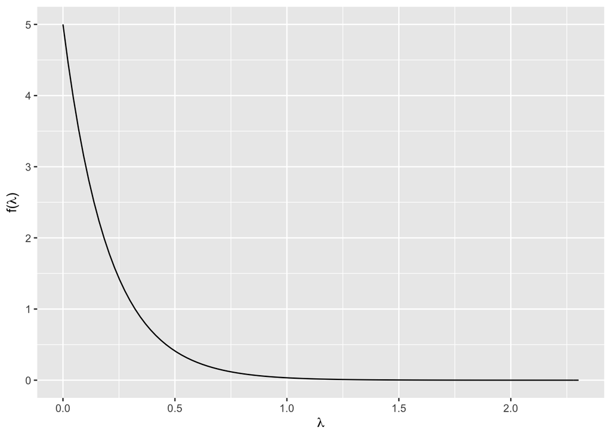

```r
plot_gamma(1,5)
```

To get the highest density interval for a gamma distribution we can go from the 0th percentile to the 95th percentile:

```r
qgamma(c(0,0.95),1,5)
```

```
## [1] 0.0000000 0.5991465
```

This gives a highest density interval of (0,0.599)

2. Repeat part a using the middle 95% approach

To get the middle 95% we can use the formula qgamma:

```r
qgamma(c(0.025,0.975),1,5)
```

```
## [1] 0.005063562 0.737775891
```

This gives a 95% CI of (0.0051,0.7378)

3. Compare the two intervals from part a and b. Are they the same? If not, how do they differ and which is more appropriate here?

4. Let mu|y ~ N(-13,2^2). Construct the 95% highest posterior density credible interval for mu

Let’s look at this:

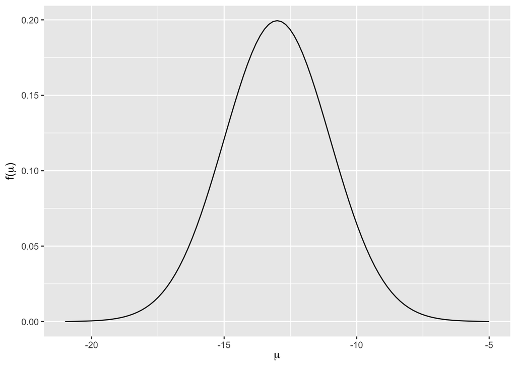

```r
plot_normal(-13,2)
```

Because this is a centered, normal distribution, the 95% CI is the same as the highest density interval. We will find that below. But I will do it here again to illustrate:

```r
qnorm(c(0.025,0.975),-13,2)
```

```
## [1] -16.919928  -9.080072
```

5. Repeat part d using the middle 95% approach

We can use the qnorm function for this:

```r
qnorm(c(0.025,0.975),-13,2)
```

```
## [1] -16.919928  -9.080072
```

This gives a 95% CI of (-16.92,-9.08)

6. Compare the two intervals from parts d and e. Are they the same? If not, why not?

These are the same because normals are centered distributions, so the 95% highest density interval should always be equal to the middle 95% interval

## Question 8.9: Hypothesis tests - Part I

For parameter pi, suppose you have Beta(1,0.8) prior model and Beta(4,3) posterior. You want to test null hypothesis pi =< 0.4 versus alternative that pi > 0.4

1. What is the posterior probability for the alternative hypothesis?

We can find this using pbeta and the posterior values. **coming back to realize I need to flip this because the formula calculates the pi < value**.

```r
post_prob <- pbeta(0.4,4,3)
post_prob <- 1 - post_prob
post_prob
```

```
## [1] 0.8208
```

The posterior probability of the alternative hypothesis is 0.8208.

2. Calculate and interpret the posterior odds

Then we can use this to calculate the posterior odds, which is the probability of H_a over the probability of H_0:

```r
post_odds <- post_prob / (1 - post_prob)
post_odds
```

```
## [1] 4.580357
```

The posterior odds is 4.58. This means that the odds that the alternative hypothesis is most likely to occur is 4.58. As in, the posterior model favors the alternative hypothesis.

3. Calculate and interpret the prior odds

This can be done using pbeta and the prior values for alpha and beta:

```r
prior_prob <- pbeta(0.4,1,0.8)
prior_prob <- 1-prior_prob
prior_prob
```

```
## [1] 0.6645398
```

The prior probability of the alternative hypothesis is 0.665

Again, we can calculate the prior odds with this:

```r
prior_odds <- prior_prob / (1-prior_prob)
prior_odds
```

```
## [1] 1.98098
```

The prior odds are 1.98, meaning there was favor for the alternative hypothesis prior to the data being observed as well.

4. Calculate and interpret the Bayes Factor

The Bayes Factor is the posterior odds over the prior odds:

```r
BF <- post_odds / prior_odds
BF
```

```
## [1] 2.312168
```

This Bayes Factor of 2.31 is over 1. This means that the plausibility of the alternative hypothesis increased in light of the observed data.

5. Putting this together, explain your conclusion about these hypotheses to someone unfamiliar with Bayesian stats:

Here we started with a null hypothesis (pi =< 0.4) and an alternative hypothesis (pi > 0.4). We can calculate the plausibility of the null and alternative hypos using our prior model. The ratio between these two values gives us the odds that we will experience our alternative hypothesis. Once we observe data, we can do the same procedure with our posterior model. We can use the Bayes factor to see the difference in the posterior and prior odds, which can give us information about how much the observed data changed the plausibility of our alternative hypothesis.

## Question 8.10: Hypo tests - Part II

Repeat exercise 8.9 for the following scenario. For parameter mu, suppose you have a N(10,10^2) prior model, a N(5,3^2) posterior, and you wish to test H_0: mu >= 5.2 and H_a: mu < 5.2

1. What is the posterior probability for H_a?

We can get this using the following code:

```r
post_prob <- pnorm(5.2,5,3)
post_prob
```

```
## [1] 0.5265765
```

The posterior probability for H_a is 0.527

2. Calculate and interpret the posterior odds

This is a ratio of the posterior probabilities of H_a and H_0

```r
post_odds <- post_prob / (1-post_prob)
post_odds
```

```
## [1] 1.112274
```

The posterior odds are 1.11 which favors the alternative hypothesis.

3. Calculate and interpret the prior odds

This is a ratio of the prior probability of H_a and H_0

```r
prior_probs <- pnorm(5.2,10,10)

prior_odds <- prior_probs / (1-prior_probs)
prior_odds
```

```
## [1] 0.4611631
```

The prior odds are 0.461 which favors the null hypothesis

4. Calculate and interpret the Bayes Factor

```r
BF <- post_odds / prior_odds
BF
```

```
## [1] 2.411888
```

The BF is 2.411, which is over 1. This means that in light of the observed data the plausibility for the alternative hypothesis increased.

5. Explain your conclusion.

Here we started with a null hypothesis (mu => 5.2) and an alternative hypothesis (mu < 5.2). We can calculate the plausibility of the null and alternative hypos using our prior model. The ratio between these two values gives us the odds that we will experience our alternative hypothesis. Once we observe data, we can do the same procedure with our posterior model. We can use the Bayes factor to see the difference in the posterior and prior odds, which can give us information about how much the observed data changed the plausibility of our alternative hypothesis.

## Question 8.14: Climate change - estimation

Let pi denote the proportion of US adults that do not believe in climate change. We’ll survey n adults and count up the number of these that don’t believe in climate change, Y.

1. Explain which Bayesian model is appropriate for this analysis:

This is a Beta-Binomial model because we are looking at a binary variable (believing or not in climate change) and counting the number Y of n adults surveyed.

2. Specify and discuss your own prior model for pi

I would **hope** this would be a low pi, like 0.1, but in reality I know its higher than that. Perhaps a mean of around 0.3. So I would choose a prior Beta(2,4).

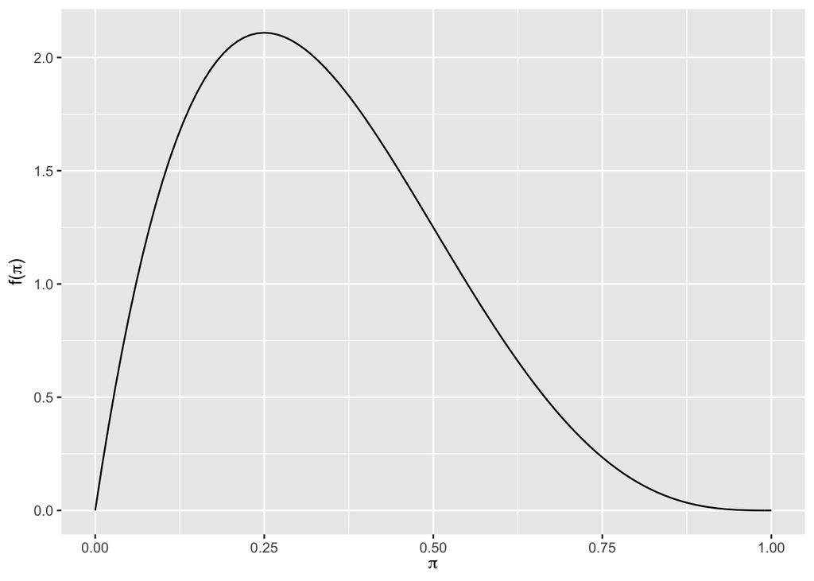

```r
plot_beta(2,4)
```

3. We’ll use the author’s Beta(1,2) (that’s close to mine!) prior for pi. How does your prior understanding differ from that of the authors.

It’s very similar! The mean value is the same. The author is just a tab bit less sure than I am.

4. Using pulse_of_the_nation data from bayesrules to report the sample proportion of surveyed adults with the opinion that climate_change is Not Real At All.

First let’s load up the data:

```r
data("pulse_of_the_nation")
```

Then I’m going to get a quick summary, just to see what data is in here:

```r
summary(pulse_of_the_nation)
```

```
##      income            age                party
##  Min.   :  5.00   Min.   :18.00   Democrat   :327
##  1st Qu.: 55.00   1st Qu.:37.00   Independent:425
##  Median : 80.00   Median :50.00   Republican :248
##  Mean   : 90.47   Mean   :49.41
##  3rd Qu.:114.00   3rd Qu.:61.00
##  Max.   :500.00   Max.   :99.00
##                         trump_approval           education        robots
##  Neither approve nor disapprove: 58    College degree :313   Likely  :199
##  Somewhat Approve              :139    Graduate degree:203   Unlikely:801
##  Somewhat disapprove           : 92    High school    :191
##  Strongly Approve              :251    Other          : 18
##  Strongly disapprove           :460    Some college   :275
##
##                        climate_change  transformers
##  Not Real At All              :150    Min.   :0.000
##  Real and Caused by People    :655    1st Qu.:0.000
##  Real but not Caused by People:195    Median :1.000
##                                       Mean   :1.323
##                                       3rd Qu.:2.000
##                                       Max.   :5.000
##                   science_is_honest                  vaccines_are_safe
##  Neither Agree nor Disagree: 19     Neither Agree nor Disagree: 16
##  Somewhat Agree            :353     Somewhat Agree            :206
##  Somewhat Disagree         :144     Somewhat Disagree         : 76
##  Strongly Agree            :377     Strongly Agree            :642
##  Strongly Disagree         :107     Strongly Disagree         : 60
##
##      books         ghosts        fed_sci_budget earth_sun
##  Min.   :   0.00   No :621   About Right:345    Mode :logical
##  1st Qu.:   2.00   Yes:379   Too High   :155    FALSE:449
##  Median :   5.00             Too Low    :500    TRUE :551
##  Mean   :  22.01
##  3rd Qu.:  17.00
##  Max.   :1000.00
##            wise_unwise
##  Happy but Unwise:522
##  Wise but Unhappy:478
##
##
##
##
```

Interesting data we have here…the climate one has three possible responses

Okay, now I will grab just the variable we need and then look at the proportion of non-believers on the issue of climate_change:

```r
climate <- pulse_of_the_nation |>
  select(climate_change)

head(climate)
```

```
## # A tibble: 6 × 1
##   climate_change
##   <fct>
## 1 Real and Caused by People
## 2 Real and Caused by People
## 3 Real but not Caused by People
## 4 Not Real At All
## 5 Real and Caused by People
## 6 Real and Caused by People
```

Now to tally it up:

```r
climate |>
  group_by(climate_change) |>
  tally()
```

```
## # A tibble: 3 × 2
##   climate_change                    n
##   <fct>                         <int>
## 1 Not Real At All                 150
## 2 Real and Caused by People       655
## 3 Real but not Caused by People   195
```

The amount of people who responded ‘Not Real At All’ is 150. Now I can also add a proportion. Just mathing it, we can use the Y = 150 over the full n = 1000. This provides a proportion of 0.15

Using R to do this all at once, we can try this:

```r
climate |>
  group_by(climate_change) |>
  tally() |>
  mutate(proportion = n/sum(n))
```

```
## # A tibble: 3 × 3
##   climate_change                    n proportion
##   <fct>                         <int>      <dbl>
## 1 Not Real At All                 150      0.15
## 2 Real and Caused by People       655      0.655
## 3 Real but not Caused by People   195      0.195
```

5. In light of the Beta(1,2) prior and data, calculate and interpret a middle 95% posterior credible interval for pi.

First, I will calculate the posterior model using the data and the prior:

```r
summarize_beta_binomial(alpha = 1,beta=2,y=150,n=1000)
```

```
##       model alpha beta      mean      mode          var         sd
## 1     prior     1    2 0.3333333 0.0000000 0.0555555556 0.23570226
## 2 posterior   151  852 0.1505484 0.1498501 0.0001273741 0.01128601
```

This gives a posterior Beta(151,852).

Then we can construct a 95% confidence interval.

```r
#0.025th & 0.975th quantiles of the Beta(151,852) posterior
qbeta(c(0.025,0.975),151,852)
```

```
## [1] 0.1291000 0.1733164
```

This gives a 95% CI of (0.129, 0.173). This means that there is a 95% posterior probability that between 13% and 17% of people do not believe in climate change.

## Question 8.15: climate change - hypo testing

Suppose we want to test a claim with hypo testing where

$H_0: \pi <= 0.1$

$H_a: \pi > 0.1$

1. What decision might you make about these hypos using the credible interval from the previous exercise?

I would believe that the alternative hypothesis is more plausible given the confidence interval we produced of (13%, 17%)

2. Calculate and interpret the posterior probability of H_a

We can do this using pbeta:

```r
post_probs <- pbeta(0.1,151,852)
post_probs
```

```
## [1] 3.127498e-07
```

So this value feels very wrong…

Ah! This formula is giving the probability that pi is < 0.1 and I need pi > 0.1. So I can take this 1 minus this value.

```r
post_probs <- 1-post_probs
post_probs
```

```
## [1] 0.9999997
```

Okay, this gives that the posterior probability of the alternative hypothesis is basically 1 (0.999).

3. Calculate and interpret the Bayes Factor for the hypo test:

So first I need to grab the posterior odds, prior probability and prior odds. I need to do the same thing I did above to flip the values for prior probability

```r
#posterior odds
post_odds <- post_probs / (1-post_probs)
post_odds
```

```
## [1] 3197444
```

```r
#prior odds
prior_probs <- pbeta(0.1,1,2)
prior_probs <- 1 - prior_probs

prior_odds <- prior_probs / (1-prior_probs)
prior_odds
```

```
## [1] 4.263158
```

This gives me a prior odds of 4.26 and a posterior odds of 3197444

With these two values, I can find the Bayes Factor:

```r
post_odds / prior_odds
```

```
## [1] 750017.6
```

The Bayes Factor here is 750017.6. This means that the plausibility for the alternative hypothesis increased *dramatically* in light of the observed data.

4. Putting this together, explain your conclusion about pi

Putting all of this together we can see that while the prior odds was slightly in favor of the alternative hypothesis that pi > 0.1, in light of the data with a sample of 1000 we are much much more confident in the alternative hypothesis. (Which is sad honestly, that we can’t reduce the number of people who don’t believe in climate change to under 10%)

## Question 8.16: Climate Change with MCMC - simulation

Repeat and build upon your climate change analysis using MCMC simulation

1. Simulate the posterior model of pi using rstan, 4 chains, and 10000 iterations

Back to MCMC! Let’s follow the steps using an n of 1000, Y of 150, Beta(1,2)

```r
#step 1: define the model

cc_model <- "
data {
int<lower = 0, upper = 1000> Y;
}
parameters {
real<lower = 0, upper = 1>pi;
}
model {
Y ~ binomial(1000,pi);
pi ~ beta(1,2);
}
"

#Step 2: simulate the posterior
cc_sim <- stan(model_code = cc_model,data=list(Y=150),chains=4,iter=5000*2,seed=369)
```

```
## Trying to compile a simple C file
```

2. Produce and discuss trace plots, density plots and autocorrelation plots:

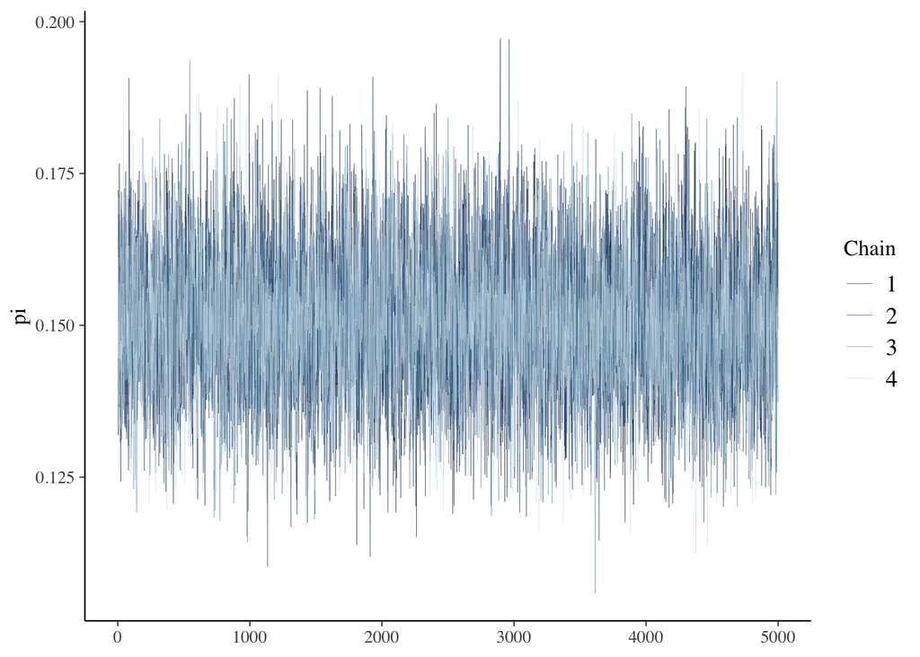

```r
#trace plot
mcmc_trace(cc_sim,pars="pi",size=0.1)
```

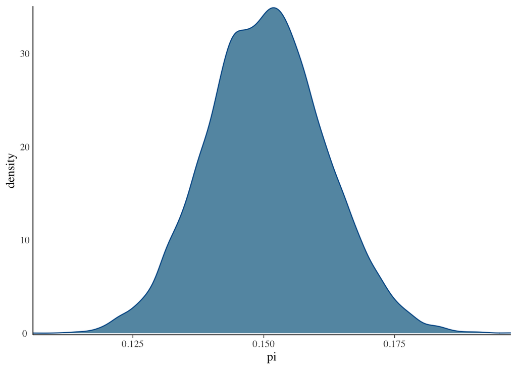

```r
#density plot
mcmc_dens(cc_sim,pars="pi") +
  yaxis_text(TRUE) +
  ylab("density")
```

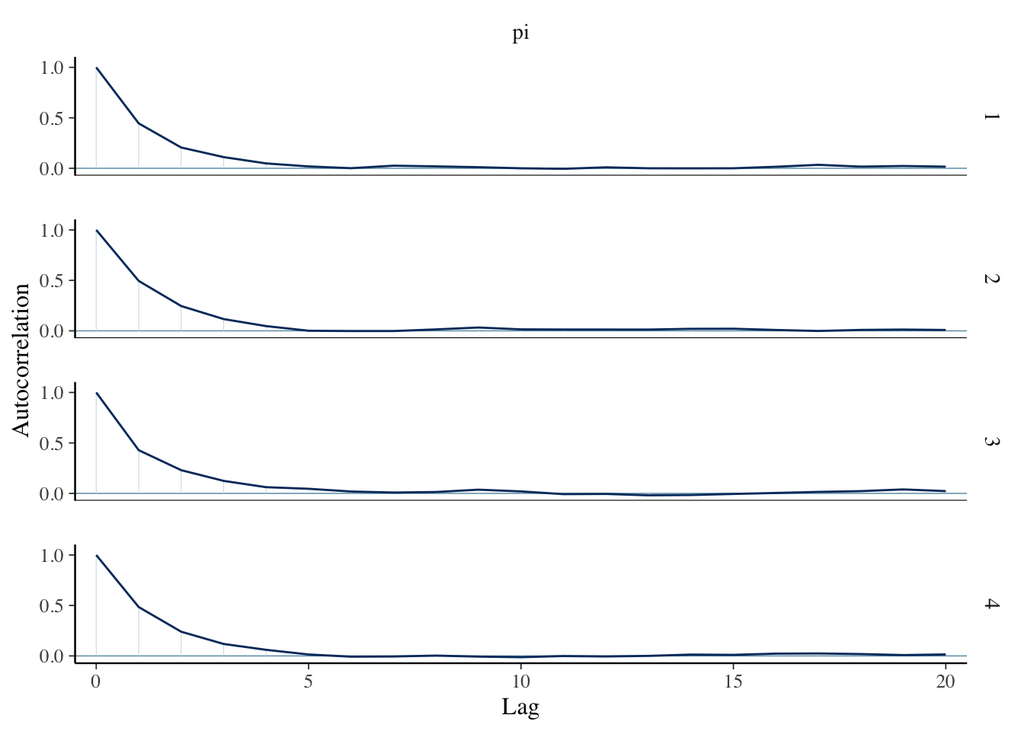

```r
#autocorrelation
mcmc_acf(cc_sim,pars="pi")
```

These all look pretty good, saying that the MCMC is acting like an independent sample and there is not obvious stuck or slow mixing.

3. Report the effective sample size ratio and R-hat values for the simulation:

```r
#calculate the effective sample size ratio

neff_ratio(cc_sim,pars=c("pi"))
```

```
## [1] 0.3516694
```

```r
#rhat value
rhat(cc_sim, pars="pi")
```

```
## [1] 1.000316
```

R-hat looks at the combined variability of the model with the within-chain variability. A value of 1 would signal stable variability. Over one shows some issues with stability and over 1.05 would be a red flag. Here we have 1.0003 which is a good value.

## Question 8.17: climate change with MCMC - estimation and hypo testing

1. Use MCMC simulation to approximate a middle 95% posterior credible interval for pi using tidy() and calculation from chain values

First with the tidy() summaries:

```r
tidy(cc_sim,conf.int=TRUE,conf.level=0.95)
```

```
## # A tibble: 1 × 5
##   term  estimate std.error conf.low conf.high
##   <chr>    <dbl>     <dbl>    <dbl>     <dbl>
## 1 pi       0.150    0.0113    0.129     0.173
```

This gives a 95% CI (0.129,0.173) meaning that there is a 95% posterior probability that between 13% and 17% of people do not believe in climate change.

Using a fuller calculation with the posterior values we can also find a CI. First we store the chains in a data frame and then calculate the summaries:

```r
#store the chains into a data frame
climate_chain_df <- as.data.frame(cc_sim,pars="lp__",include=FALSE)
dim(climate_chain_df)
```

```
## [1] 20000     1
```

```r
climate_chain_df |>
  summarize(post_mean = mean(pi),
            post_median = median(pi),
            post_mode = sample_mode(pi),
            lower_95 = quantile(pi,0.025),
            upper_95 = quantile(pi,0.975))
```

```
##   post_mean post_median post_mode  lower_95  upper_95
## 1 0.1504714   0.1503912 0.1518499 0.1286802 0.1730725
```

This gives the exact same values for the CI (0.129,0.173).

2. Use the MCMC simulation to approximate the posterior probability that pi > 0.1

We can do this by looking at the pi values that fulfill this pi condition:

```r
climate_chain_df |>
  mutate(exceeds = pi > 0.1) |>
  tabyl(exceeds)
```

```
##  exceeds     n percent
##     TRUE 20000       1
```

This is saying that the posterior probability that pi > 0.1 is 1…this feels incorrect. Let me examining my posterior probability:

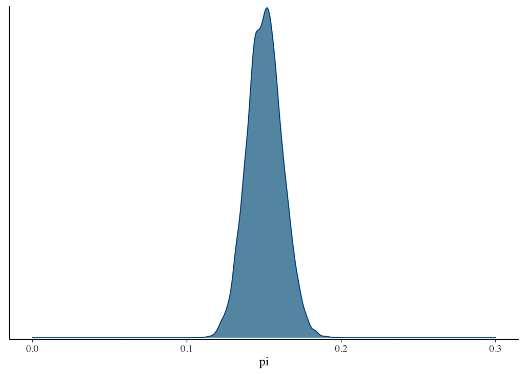

```r
#mcmc posterior approximation
mcmc_dens(cc_sim,pars="pi") +
  lims(x=c(0,0.3))
```

Okay, so maybe it’s right! The spread of this is fairly tight, and values below 0.1 have no density.

3. How close are the approximations in parts a and b to the actual corresponding posterior values calculated in questions 8.14 and 8.15?

The actual values I got are below:

95% CI of (0.129, 0.173)

posterior probability of pi > 0.1 = 0.999

The approximations from MCMC I got are here:

95% CI (0.129,0.173)

posterior probability of pi > 0.1 = 1

These approximation values are pretty much dead on with the posterior values I calculated with the sample.

## Question 8.18: Climate Change with MCMC - prediction

1. Suppose you survey 100 more adults. Use MCMC simulation to approximate the posterior predictive model of Y’, the number that don’t believe in climate change. Construct a histogram visualization of the model

We can use rbinom to simulate one Bin(100,pi) outcome Y’ from each of the 20k pi chain values:

```r
#set the seed
set.seed(369)

#predict a value of Y' for each pi value in the chain
climate_chain_df <- climate_chain_df |>
  mutate(y_predict=rbinom(length(pi),size = 100,prob=pi))

#check it out
climate_chain_df |>
  head(3)
```

```
##          pi y_predict
## 1 0.1440927        12
## 2 0.1447705         9
## 3 0.1514545        18
```

Then we can plot it out:

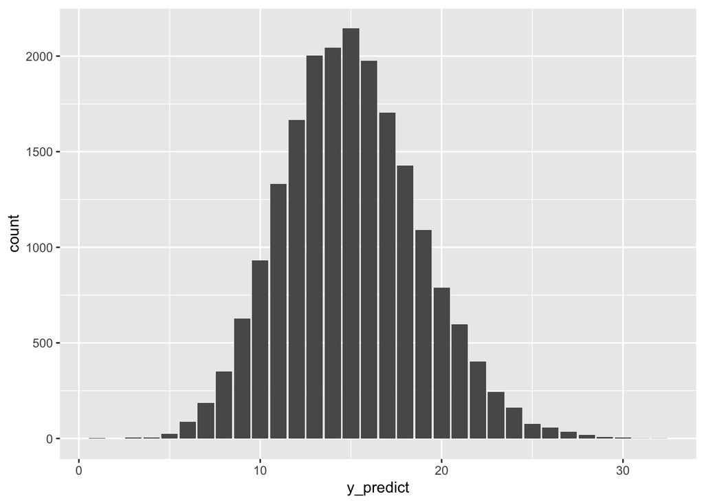

```r
#plot 20k predictions
ggplot(climate_chain_df,aes(x=y_predict)) +
  stat_count()
```

This looks like the most likely value is 15 of the next 100 will not believe in climate change. This tracks to the sample we first had where 150 of 1000 did not believe. The range will reasonably be between about 5 and 28.

2. Summarize your observations of the posterior predictive model of Y’

We can get more precise than my estimates above:

```r
climate_chain_df |>
  summarize(mean = mean(y_predict),
            lower_95 = quantile(y_predict,0.025),
            upper_95 = quantile(y_predict,0.975))
```

```
##      mean lower_95 upper_95
## 1 15.0049        8       23
```

This gives a mean of 15 and 95% chance that the figure is between 8 and 23.

3. Approximate the probability that at least 20 of the 100 people don’t believe in climate change

We are looking for the following:

$P(Y'>=20|y=150) = \sum_{y'=20}^{100}f(y'|y=150)$

$f(y'|y) = \int{f(y'|\pi)f(\pi|y)d\pi}$

We did the work in our simulation to predict 100 values based on the observed data we previously collected: f(y’|y=150). So here, we can sum all of those values (y’) between 20 and 100:

```r
predict_20 <- climate_chain_df |>
  filter(y_predict>=20)

nrow(predict_20) / nrow(climate_chain_df)
```

```
## [1] 0.11955
```

Here this shows that the probability of at least 20 people not believing in climate change is about 12%

## Question 8.19: Penguins - estimation

Let mu denote the typical flipper length in mm among Adelie penguin species. To learn about mu, we’ll use flipper measurements on a sample of Adelie penguins

1. Explain which Bayesian model is appropriate for this analysis

This would be a normal normal because we are looking at the mu

2. You prior understanding is that the average flipper length is about 200mm but you aren’t sure. It’s plausible it could be as low as 140mm or high as 260mm. Specify an appropriate prior model for mu

I will guess the mean is about 200, landing in the middle of the range and is my original guess. Then for the range I will start off with 60. My prior model will then be: N(200,60^2)

Let’s look at this:

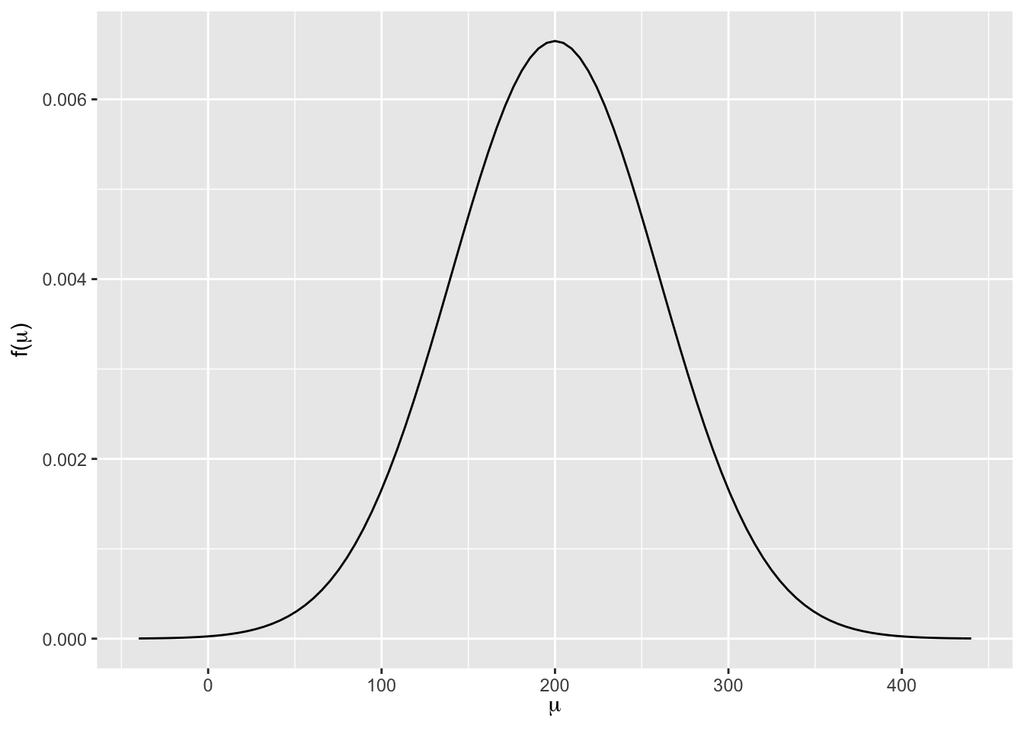

```r
plot_normal(200,60)
```

This is a bit too wide. Let’s cut down on the sd value. Trying 40

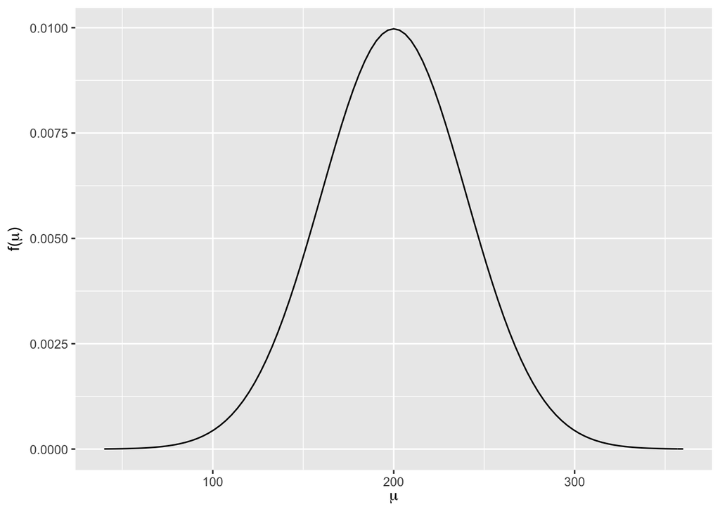

```r
plot_normal(200,40)
```

This looks better to have most of the density between 140 and 260.

3. Using the penguins_bayes data in the bayesrules package, find how many data points there are for species and the sample mean of flipper_length_mm

```r
#grabbing the data
data("penguins_bayes")

#get the observations and the sample mean for flipper_length
penguins <- penguins_bayes |>
  filter(species=="Adelie") |>
  drop_na() |>
  summarize(avg_flip = mean(flipper_length_mm,na.rm=TRUE),
            sd_flip = sd(flipper_length_mm,na.rm=TRUE),
            species_num = n())

penguins
```

```
## # A tibble: 1 × 3
##   avg_flip sd_flip species_num
##      <dbl>   <dbl>       <int>
## 1     190.    6.52         146
```

This gives that the average of this sample is 190.1 and the number of species data points is 146

4. In light of the prior and data, calculate and interpret a middle 95% posterior credible interval for mu. First you have to specify a posterior model for mu

First to calculate a posterior for mu. Note this is for mu and not for the full distribution. We can grab the sd for mu from the above summary:

```r
summarize_normal_normal(200,sd=sqrt(40),y_bar=190.1027,n=146,sigma=6.521825)
```

```
##       model     mean     mode        var        sd
## 1     prior 200.0000 200.0000 40.0000000 6.3245553
## 2 posterior 190.1743 190.1743  0.2892237 0.5377952
```

This gives a posterior of N(190.1743,0.289).

To get a 95% credible interval we can use qnorm

```r
qnorm(c(0.025,0.975),mean=190.1743,sd=0.538)
```

```
## [1] 189.1198 191.2288
```

This gives a 95% CI of (189.1,191.2). This means that there is a 95% posterior probability that the mean is between 189.1 and 191.2

## Question 8.20: Penguins - hypothesis testing

Continue examining the Adelie penguins

1. Hypothesize that the average Adelie flipper hypo test is between 200mm and 220mm. State this as a formal hypo test

$H_0: \mu < 200 | \mu > 220$

$H_a: 200 < \mu < 220$

2. What decision might you make about these hypotheses using the credible interval from the previous exercise

I would be inclined to believe that the null hypothesis is more plausible. The posterior values we get for mu in our data centers around 190 and the variance is extremely small, so the likelihood that it’s between 200 and 220 is not very likely.

3. Calculate and interpret the posterior probability that your hypothesis is true

This is a two sided hypothesis test. We need to evaluate the probability that the value of mu is both above 200 and less than 220. This is a joint probability and we can multiply the probability of both of those conditions to assess the posterior probability.

```r
post_low <- pnorm(200,190.1743,0.538)
post_high <- 1 - pnorm(220,190.1743,0.538)

post_prob <- post_low * post_high
post_prob
```

```
## [1] 0
```

4. Putting this together, explain your conclusion about mu

We saw that the posterior model for mu centered around 190 with a very small variance and 95% CI between 189 and 191. Given how tight the estimation was, we are fairly confident in the mu being around 190 and it would not be very plausible to see values for mu far from 190.

## Question 8.21: Loons - estimation

The loon is a species of bird common to Ontario. Let lambda denote the typical number of loons observed across a 100-hr period.

1. Explain which Bayesian model is appropriate

This is a Gamma-Poisson because we are dealing with the rate of occurrence over a time interval

2. Your prior understanding is that the typical rate is 2 per 100 hrs with sd = 1 per 100 hrs. Specify a prior model for lambda and explain

Here I will use the following formulas for the Gamma distribution and the values provided to us in this question to arrive at a sensible prior model.

avg = s/r

var = s/r^2

sd = sqrt(var)

2 = s/r

1 = sqrt(s) / r

Using these two formulas, I can solve for s and r:

2r = s

1 = sqrt(2r) / r

r = sqrt(2r)

r^2 = 2r

r = 2

2 = s/2

4 = s

This gives us a **Gamma(4,2)**

3. The loons data contains counts in different observation periods. How many data points do we have and what’s the average loon count?

First to load the data:

```r
data("loons")
```

Then I’ll take a quick peak:

```r
head(loons)
```

```
## # A tibble: 6 × 5
##    year count hours count_per_hour count_per_100
##   <dbl> <dbl> <dbl>          <dbl>         <dbl>
## 1  2000     0  144.        0                   0
## 2  2001     7  154.        0.0456              5
## 3  2002     0  228.        0                   0
## 4  2003     1  249.        0.00402             0
## 5  2004     1  204.        0.00491             0
## 6  2005     4  246.        0.0163              2
```

Okay, so we are looking for the count_per_100 variable here for average and we can take all the data points:

```r
loons_df <- loons |>
  summarize(ct_100_avg = mean(count_per_100,na.rm=TRUE),
            data_pts = n())
loons_df
```

```
## # A tibble: 1 × 2
##   ct_100_avg data_pts
##        <dbl>    <int>
## 1        1.5       18
```

This gives the average count in 100 hr periods is 1.5 and the observations are 18

4. In light of the prior and data, calculate and interpret a middle 95% posterior credible interval for lambda. First you need to specify posterior model of lambda

First to use the summary to find the posterior model:

```r
summarize_gamma_poisson(4,2,sum_y=1.5*18,n=18)
```

```
##       model shape rate mean mode    var        sd
## 1     prior     4    2 2.00  1.5 1.0000 1.0000000
## 2 posterior    31   20 1.55  1.5 0.0775 0.2783882
```

This gives a posterior Gamma(31,20)

Then using this, we can calculate the 95% CI using qgamma

```r
qgamma(c(0.025,0.975),31,20)
```

```
## [1] 1.053150 2.141343
```

The 95% CI is (1.05, 2.14). This means that there is a 95% posterior probability that lambda is between 1.05 and 2.14.

## Question 8.22: Loons - Hypo testing

1. Hypothesize that you anticipate a rate of less than 1 per observation period. State this as a formal hypo test:

$H_0: \lambda >= 1$

$H_a: \lambda < 1$

2. What decision might you make about these hypos using the credible interval from previous exercise?

The CI we got for lambda were both above 1 so I would expect to favor the null hypothesis.

3. Calculate and interpret the posterior probability that your hypo is true

We can get the posterior probability using pgamma and the posterior values for shape and rate

```r
pgamma(1,31,20)
```

```
## [1] 0.01347468
```

The posterior probability that lambda is less than 1 is not very high (1.3%). This shows that we have high favor for the null hypothesis.

Let’s check out the graph to see if that checks out

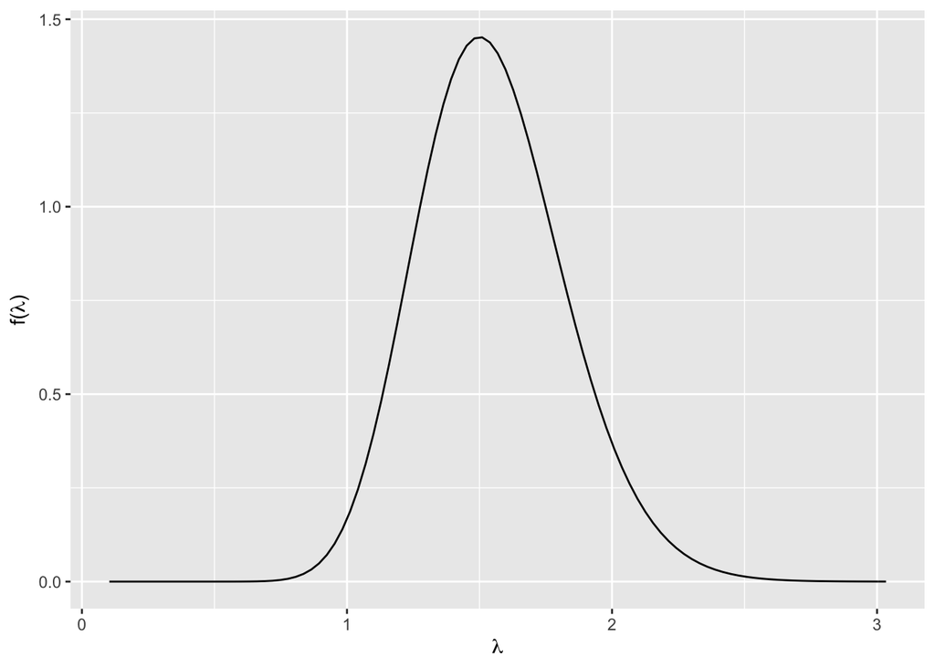

```r
plot_gamma(31,20)
```

This seems to check out. Most of the distribution is falling above 1, though there is a small piece that falls below 1.

4. Putting this together, explain your conclusion about lambda

## Question 8.23: Loons with MCMC - simulation

1. Simulate the posterior model of lambda, the typical rate of loon sightings per observation period using rstan 4 chains and 10000 iterations per chain

First, let’s grab our vector of observations:

```r
loons_Y <- as.vector(loons$count_per_100)
loons_Y
```

```
##  [1] 0 5 0 0 0 2 0 2 1 1 0 4 2 0 3 3 1 3
```

Then we can use that within the rstan model when it calls for an observations vector

```r
#step 1: define the model

loons_model <- "
data {
int<lower = 0> Y[18];
}
parameters {
real<lower = 0>lambda;
}
model {
Y ~ poisson(lambda);
lambda ~ gamma(4,2);
}
"

#step 2: simulate the posterior

loons_sim <- stan(model_code = loons_model, data=list(Y=loons_Y),
               chains=4,iter=5000*2,seed=369)
```

```
## Trying to compile a simple C file
```

2. Perform some diagnostics to confirm the simulation has stabilized

We’ll do both visual and analytic diagnostics below

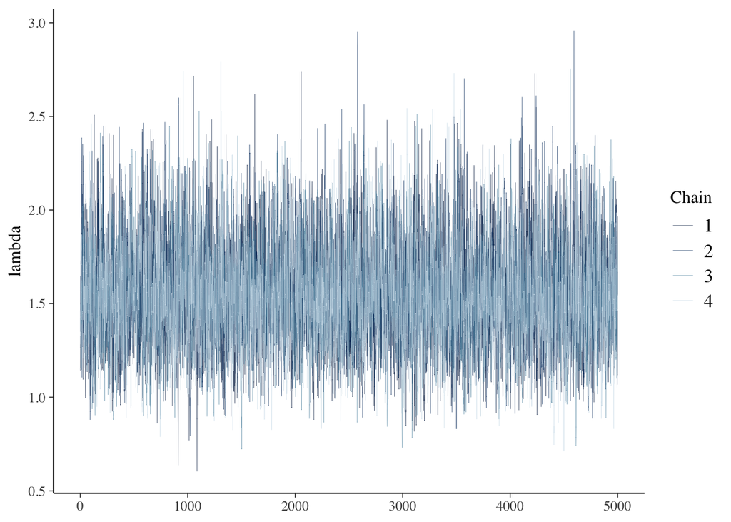

```r
#trace plot
mcmc_trace(loons_sim,pars="lambda",size=0.1)
```

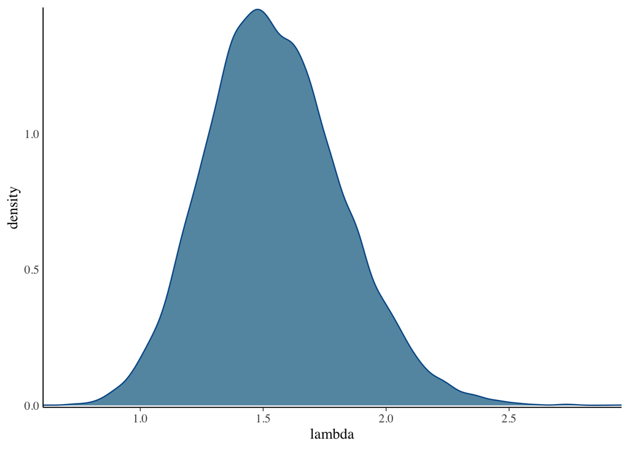

```r
#density plot
mcmc_dens(loons_sim,pars="lambda")+
  yaxis_text(TRUE)+
  ylab("density")
```

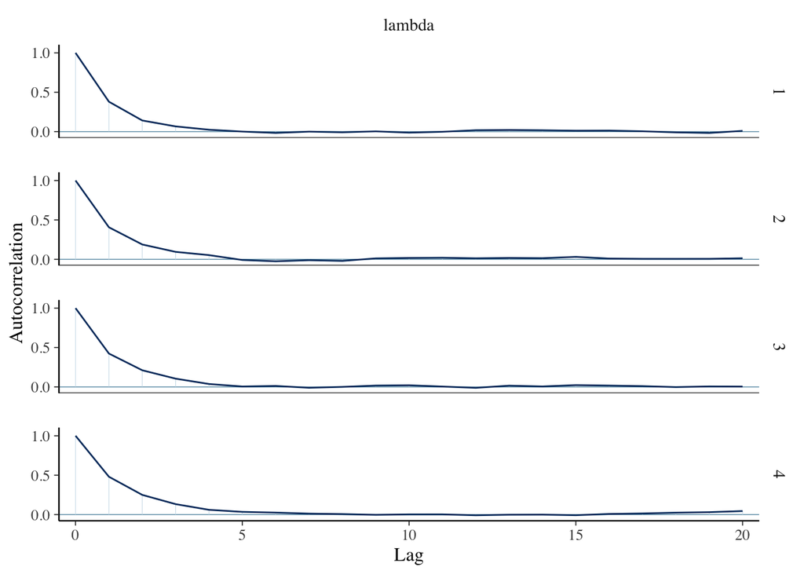

```r
#autocorrelation
mcmc_acf(loons_sim,pars="lambda")
```

These all look good with fast mixing, not stuck points. Now for the analytical checks

```r
#Neff ratio

neff_ratio(loons_sim,pars="lambda")
```

```
## [1] 0.3914139
```

```r
#rhat

rhat(loons_sim,pars="lambda")
```

```
## [1] 1.000618
```

This gives a Neff of over 0.1 so we’re not worried and an rhat of about 1 and less than 1.05.

3. Use MCMC simulation to approximate a middle 95% posterior credible interval for lambda using tidy and direct calculation

Using tidy we can get values:

```r
tidy(loons_sim,conf.int = TRUE,conf.level=0.95)
```

```
## # A tibble: 1 × 5
##   term   estimate std.error conf.low conf.high
##   <chr>     <dbl>     <dbl>    <dbl>     <dbl>
## 1 lambda     1.53     0.275     1.05      2.12
```

This provides a 95% CI of (1.05, 2.12)

Now we have to save this as a dataframe before doing more summary:

```r
loons_chain_df <- as.data.frame(loons_sim,pars="lp__",include=FALSE)
dim(loons_chain_df)
```

```
## [1] 20000     1
```

Then let’s get the summary calculations:

```r
loons_chain_df |>
  summarize(post_mean = mean(lambda),
            post_median = median(lambda),
            post_mode = sample_mode(lambda),
            lower_95 = quantile(lambda,0.025),
            upper_95 = quantile(lambda,0.975))
```

```
##   post_mean post_median post_mode lower_95 upper_95
## 1  1.547667    1.531036  1.478437 1.050305 2.123277
```

This gives a 95% CI of (1.05,2.12) as well

4. Use MCMC to approximate the posterior probability that lambda is < 1

```r
loons_chain_df |>
  mutate(exceeds = lambda < 1) |>
  tabyl(exceeds)
```

```
##  exceeds     n percent
##    FALSE 19721 0.98605
##     TRUE   279 0.01395
```

This says that the posterior probability that lambda is less than 1 is about 0.01395 (1.4%).

5. How close are the approximations to the actual posterior values you calculated?

Actual calculations:

Posterior probability of lambda < 1 = 0.01347468

95% CI = (1.05, 2.14)

posterior mean = 1.55

Approximations:

Posterior probability of lambda < 1 = 0.01395

95% CI = (1.05,2.12)

posterior mean = 1.548

All of these values are very similar to the calculated values we found before.

## Question 8.24: Loons with MCMC - prediction

1. Use MCMC simulation to approximate the posterior predictive mode of Y’ and construct a histogram visualization

```r
#set the seed
set.seed(369)

#predict a value of Y' for each lambda value in the chain
loons_chain_df <- loons_chain_df |>
  mutate(y_predict=rpois(n=20000,lambda))

#check it out
loons_chain_df |>
  head(3)
```

```
##     lambda y_predict
## 1 1.142356         0
## 2 1.325783         0
## 3 1.264155         2
```

Then plot it out:

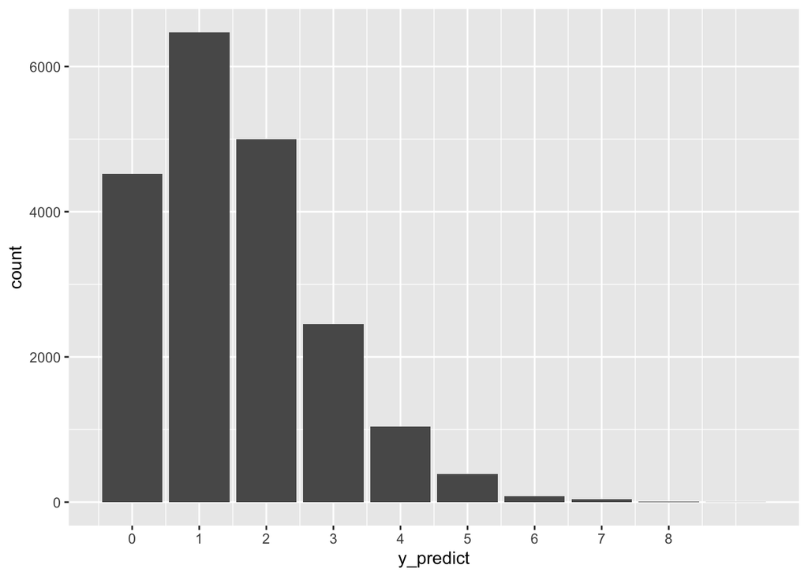

```r
#plot 20k predictions
ggplot(loons_chain_df,aes(x=y_predict)) +
  stat_count() +
  scale_x_continuous(breaks = seq(0,8,1))
```

This gives the most likely value to be 1.

2. Summarize your observations of the posterior predictive model of Y’

```r
loons_chain_df |>
  summarize(mean = mean(y_predict),
            lower_95 = quantile(y_predict,0.025),
            upper_95 = quantile(y_predict,0.975))
```

```
##      mean lower_95 upper_95
## 1 1.53775        0        5
```

This provides a mean of 1.54 and a 95% chance that the number of loons the birdwatcher will see in the next 100-hour period is between 0 and 5

3. Approximate the probability that the birdwatcher observed 0 loons in their next observation period

Here we can employ the technique we used above where we take the sum of our observed values in the model we simulated. We can sum all of the instances where y’ was 0 and divide that by the total number of values we observed:

```r
predict_0 <- loons_chain_df |>
  filter(y_predict == 0)

nrow(predict_0) / nrow(loons_chain_df)
```

```
## [1] 0.2259
```

Using the data, we can see that the probability that the birdwatcher sees zero birds in their next birdwatching period is about 23%.